# Pseudobulk tutorial: from single cells to a bulk RNA-seq count table

A first introduction using mouse placenta single-cell data (GEO GSE347706)

2026-10-14

# 1. What is pseudobulk?

A single-cell RNA-seq experiment measures gene expression in **each cell**. One experiment can have 100,000 to 500,000 cells or more. This is a lot of data. It needs a big computer, and the analysis tools are different from the bulk RNA-seq tools that many scientists already know.

**Pseudobulk** is a simple idea that makes single-cell data look like bulk RNA-seq data again:

> For each cell type, in each sample, we **add up the raw counts of all the cells**. The result is one column of counts per cell type per sample, just like a bulk RNA-seq sample.

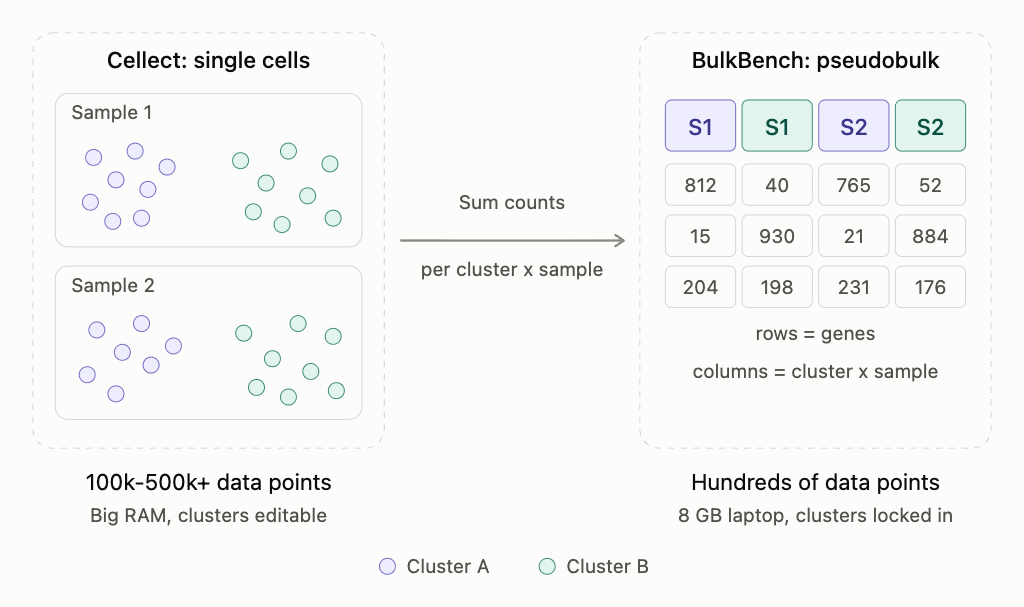

The figure shows the trade-off:

| Single cells | Pseudobulk |
| --- | --- |
| 100k to 500k+ data points (cells) | Hundreds of data points (cell type x sample) |
| Needs a big computer (a lot of RAM) | Works on a normal laptop (about 8 GB RAM) |
| You can still change the clusters | The clusters are **locked in** |
| Needs special single-cell tools | Works with bulk tools: **edgeR, DESeq2, limma** |

**“Locked in”** means this: the table is made from the cell types you have now. If you change the cell types later (for example, you split one cluster into two), you must make the table again. This is easy: you just run this document again.

## Words we use in this tutorial

| Word | Meaning |
| --- | --- |
| **Raw counts** | The number of RNA molecules counted for each gene in each cell. Always whole numbers: 0, 1, 2, 3 … |
| **Cluster** or **cell type** | A group of similar cells, for example “B cells”. |
| **Sample** or **replicate** | One biological unit: one patient, one mouse, one cell line culture. |
| **Pseudosample** | One cell type in one sample. This becomes one column in the final table. |

# 2. Install the software packages

You only need to run this once. If a package is already installed, it will be skipped.

- **Seurat**: the most common R package for single-cell data.
- **edgeR**: a bulk RNA-seq package. We use it at the end, to show that the table is ready for bulk analysis.
- **openxlsx**: writes Excel files.

```r
# Packages from CRAN (the general R repository)
cran_packages <- c("BiocManager", "Seurat", "openxlsx", "knitr")

for (p in cran_packages) {
  if (!requireNamespace(p, quietly = TRUE)) {
    install.packages(p, repos = "https://cloud.r-project.org")
  }
}

# Packages from Bioconductor (the repository for biology packages)
bioc_packages <- c("edgeR")

for (p in bioc_packages) {
  if (!requireNamespace(p, quietly = TRUE)) {
    BiocManager::install(p, ask = FALSE, update = FALSE)
  }
}

# Check that everything is installed
all_packages <- c(cran_packages, bioc_packages)
installed <- vapply(all_packages, requireNamespace, logical(1), quietly = TRUE)
if (!all(installed)) {
  stop("These packages did not install: ",
       paste(all_packages[!installed], collapse = ", "))
}
```

> **Note on package names.** Every function in this tutorial is written with its package name in front, like `Seurat::AggregateExpression()`. The two colons `::` mean “use this function from this package”. This way you can always see where each function comes from.

# 3. Download the example dataset

We use a public mouse dataset from GEO (accession GSE347706). The study asked: **does stress during pregnancy change the placenta?**

- **Stress group**: 3 pregnant mice were stressed for 2 hours every day.
- **Control group**: 3 pregnant mice were not stressed.
- The placentas were collected, and about 27,000 single cells were sequenced.
- Each sample is the placentas from **one mother** (one litter).

The authors uploaded a ready-to-use **Seurat object** (a `.rds` file). The download is about **300 MB**. It only happens once. The next time you run this document, R loads the file from your computer.

```r
data_file <- "GSE347706_placenta_scRNAseq_processed_seurat.rds"
data_url  <- paste0("https://ftp.ncbi.nlm.nih.gov/geo/series/GSE347nnn/",
                    "GSE347706/suppl/", data_file)

if (!file.exists(data_file)) {
  options(timeout = 3600)                 # allow up to 1 hour for the download
  download.file(data_url, data_file, mode = "wb")
}

obj <- readRDS(data_file)
obj
```

```
## An object of class Seurat
## 20174 features across 27372 samples within 1 assay
## Active assay: RNA (20174 features, 2000 variable features)
##  3 layers present: data, counts, scale.data
##  4 dimensional reductions calculated: pca, integrated.cca, harmony, umap
```

## What is inside a Seurat object?

For pseudobulk, we only need two parts of the object:

1. **The raw counts**: a table with genes as rows and cells as columns.
2. **The metadata**: a table with one row per cell. It tells us which sample and which cell type each cell belongs to.

```r
meta <- obj[[]]     # the metadata table (one row per cell)

knitr::kable(head(meta[, c("Sample", "Treatment", "Batch", "cell")]),
             caption = "The first six cells in the metadata table")
```

The first six cells in the metadata table

|  | Sample | Treatment | Batch | cell |
| --- | --- | --- | --- | --- |
| Control-1_Control_One_AAACCCAAGCCGGAAT-1 | Control-1 | Control | One | Endothelial cells |
| Control-1_Control_One_AAACCCACAGCGGTCT-1 | Control-1 | Control | One | TGCs |
| Control-1_Control_One_AAACCCAGTGCGTTTA-1 | Control-1 | Control | One | Spongiotrophoblasts |
| Control-1_Control_One_AAACCCATCAAGGCTT-1 | Control-1 | Control | One | Neutrophils |
| Control-1_Control_One_AAACGAACATCGTGGC-1 | Control-1 | Control | One | VSMCs |
| Control-1_Control_One_AAACGAAGTACACGTT-1 | Control-1 | Control | One | TGCs |

## Check that the counts are really raw counts

This step is important. Pseudobulk must use **raw counts**. Bulk tools like edgeR and DESeq2 give wrong results with normalised values.

Many public Seurat objects have a layer called `counts` that does **not** contain raw counts. Raw counts are always whole numbers, so we check that.

```r
counts <- SeuratObject::LayerData(obj, assay = "RNA", layer = "counts")

counts[1:5, 1:3]     # a dot "." means zero
```

```
## 5 x 3 sparse Matrix of class "dgCMatrix"
##         Control-1_Control_One_AAACCCAAGCCGGAAT-1
## Gm19938                                        .
## Rp1                                            .
## Sox17                                         17
## Gm37587                                        .
## Mrpl15                                         .
##         Control-1_Control_One_AAACCCACAGCGGTCT-1
## Gm19938                                        .
## Rp1                                            .
## Sox17                                          .
## Gm37587                                        .
## Mrpl15                                         .
##         Control-1_Control_One_AAACCCAGTGCGTTTA-1
## Gm19938                                        .
## Rp1                                            .
## Sox17                                          .
## Gm37587                                        .
## Mrpl15                                         .
```

```r
# Are all values whole numbers?
all(counts@x == round(counts@x))
```

```
## [1] TRUE
```

The answer is `TRUE`, so the counts are raw. If you see `FALSE` with your own data, stop and find the raw counts first.

# 4. Step 1: Lock in the clusters

First we choose the metadata column that says which cell type each cell is. In this dataset the column is called `cell`. The authors already named 13 cell types.

We make a copy of this column with a clean name, `cell_type`. We also replace the symbols `Φ` and `/` in the names, because special symbols can cause problems in Excel and in file names.

```r
obj$cell_type <- gsub("MΦ/Monos", "Macrophage-Monocyte", obj$cell)

knitr::kable(as.data.frame(table(cell_type = obj$cell_type),
                           responseName = "Cells"),
             caption = "Number of cells in each cell type")
```

Number of cells in each cell type

| cell_type | Cells |
| --- | --- |
| B cells | 2124 |
| Decidual stromal cells | 1918 |
| Endothelial cells | 1465 |
| Glycogen cells | 2058 |
| Macrophage-Monocyte 1 | 1861 |
| Macrophage-Monocyte 2 | 2109 |
| Neutrophils | 1934 |
| Spongiotrophoblasts | 6182 |
| Syncytiotrophoblasts | 2035 |
| T cells | 1021 |
| TGCs | 1773 |
| VSMCs | 1834 |
| Yolk sac | 1058 |

> **This is the moment the clusters are locked in.** If you want different cell types (for example, more detailed ones), change this column now, before you go on.

# 5. Step 2: Choose the replicate column

Next we choose the column that says which **biological replicate** each cell comes from. Here it is `Sample`: each sample is one mother.

Why does this matter? Cells from the same mouse are not independent. They share the same genes, the same environment and the same lab processing. So the real number of replicates is the number of **mice**, not the number of cells. If we use cells as replicates, we get many false positive results.

```r
knitr::kable(table(obj$Sample, obj$Treatment),
             caption = "Each sample belongs to one group")
```

Each sample belongs to one group

|  | Control | Stress |
| --- | --- | --- |
| Control-1 | 4924 | 0 |
| Control-2 | 5087 | 0 |
| Control-3 | 4494 | 0 |
| Stress-1 | 0 | 2681 |
| Stress-2 | 0 | 6367 |
| Stress-3 | 0 | 3819 |

We have **3 Control and 3 Stress** samples. You need **at least 3 replicates per group** for a valid group comparison. 2 replicates per group is the minimum for the statistics to work, but it is not recommended. More is better.

# 6. Step 3: Check the number of cells in each pseudosample

Now we count the cells for each cell type in each sample. Each number becomes one column in our final table.

If a pseudosample has only a few cells (for example, fewer than 10), its counts are not reliable. You may want to remove it, or merge small cell types together.

```r
cell_table <- table(obj$cell_type, obj$Sample)
knitr::kable(cell_table, caption = "Number of cells: cell type x sample")
```

Number of cells: cell type x sample

|  | Control-1 | Control-2 | Control-3 | Stress-1 | Stress-2 | Stress-3 |
| --- | --- | --- | --- | --- | --- | --- |
| B cells | 429 | 378 | 450 | 200 | 513 | 154 |
| Decidual stromal cells | 321 | 373 | 314 | 226 | 433 | 251 |
| Endothelial cells | 387 | 162 | 104 | 137 | 460 | 215 |
| Glycogen cells | 321 | 394 | 345 | 188 | 417 | 393 |
| Macrophage-Monocyte 1 | 379 | 325 | 353 | 174 | 438 | 192 |
| Macrophage-Monocyte 2 | 560 | 456 | 329 | 151 | 496 | 117 |
| Neutrophils | 399 | 243 | 309 | 152 | 579 | 252 |
| Spongiotrophoblasts | 824 | 1306 | 1103 | 711 | 1199 | 1039 |
| Syncytiotrophoblasts | 133 | 478 | 257 | 290 | 455 | 422 |
| T cells | 226 | 143 | 157 | 62 | 297 | 136 |
| TGCs | 371 | 341 | 232 | 150 | 432 | 247 |
| VSMCs | 355 | 296 | 316 | 173 | 450 | 244 |
| Yolk sac | 219 | 192 | 225 | 67 | 198 | 157 |

```r
cat("Smallest pseudosample:", min(cell_table), "cells\n")
```

```
## Smallest pseudosample: 62 cells
```

All pseudosamples have at least 62 cells, so we keep all of them.

# 7. Step 4: Add up the raw counts

This is the main step. `Seurat::AggregateExpression()` adds up the raw counts of all cells with the same cell type **and** the same sample.

```r
# In Seurat v5, counts can be split into several layers. Join them first.
obj <- SeuratObject::JoinLayers(obj)

pseudobulk <- Seurat::AggregateExpression(
  obj,
  assays   = "RNA",
  group.by = c("cell_type", "Sample")   # one column per cell type x sample
)$RNA

dim(pseudobulk)    # genes x pseudosamples
```

```
## [1] 20174    78
```

```r
pseudobulk[c("Actb", "Gapdh", "Malat1"), 1:3]    # three well-known genes
```

```
## 3 x 3 sparse Matrix of class "dgCMatrix"
##        B cells_Control-1 B cells_Control-2 B cells_Control-3
## Actb                4547              3340              6871
## Gapdh                589               456               586
## Malat1             24960             33787             35015
```

The data shrank from **27,372 cells** to **78 pseudosamples** (13 cell types x 6 samples).

As a check, the total number of counts must be the same before and after. We only added the numbers together, we did not change them.

```r
sum(pseudobulk) == sum(counts)
```

```
## [1] TRUE
```

# 8. Step 5: Save the results

We save two tables, exactly like a bulk RNA-seq experiment:

1. **The counts table**: genes as rows, pseudosamples as columns.
2. **The sample sheet**: one row per pseudosample, with its cell type, sample, group and number of cells.

## Make the sample sheet

```r
# One row per cell type x sample, with the number of cells
sample_sheet <- as.data.frame(cell_table, stringsAsFactors = FALSE)
colnames(sample_sheet) <- c("cell_type", "sample", "n_cells")

# The same names that AggregateExpression() gave to the columns
sample_sheet$pseudosample <- paste(sample_sheet$cell_type, sample_sheet$sample, sep = "_")

# Add the group (Control or Stress) and the batch of each sample
sample_info  <- unique(meta[, c("Sample", "Treatment", "Batch")])
sample_sheet <- merge(sample_sheet, sample_info, by.x = "sample", by.y = "Sample")

# Put the rows in the same order as the columns of the counts table
sample_sheet <- sample_sheet[match(colnames(pseudobulk), sample_sheet$pseudosample),
                             c("pseudosample", "cell_type", "sample",
                               "Treatment", "Batch", "n_cells")]
rownames(sample_sheet) <- NULL

# Safety check: the two tables must be in the same order
stopifnot(identical(sample_sheet$pseudosample, colnames(pseudobulk)))

knitr::kable(head(sample_sheet), caption = "First rows of the sample sheet")
```

First rows of the sample sheet

| pseudosample | cell_type | sample | Treatment | Batch | n_cells |
| --- | --- | --- | --- | --- | --- |
| B cells_Control-1 | B cells | Control-1 | Control | One | 429 |
| B cells_Control-2 | B cells | Control-2 | Control | Two | 378 |
| B cells_Control-3 | B cells | Control-3 | Control | Two | 450 |
| B cells_Stress-1 | B cells | Stress-1 | Stress | One | 200 |
| B cells_Stress-2 | B cells | Stress-2 | Stress | Two | 513 |
| B cells_Stress-3 | B cells | Stress-3 | Stress | Two | 154 |

## Write the files

This dataset only has gene **symbols** (for example `Sox17`), not Ensembl gene IDs. If your own data has both, add both as columns.

```r
dir.create("pseudobulk_output", showWarnings = FALSE)

counts_table <- data.frame(gene = rownames(pseudobulk),
                           as.matrix(pseudobulk),
                           check.names = FALSE)

# CSV files (open in any program)
write.csv(counts_table, "pseudobulk_output/pseudobulk_counts.csv", row.names = FALSE)
write.csv(sample_sheet, "pseudobulk_output/sample_sheet.csv",      row.names = FALSE)

# One Excel file with two sheets
openxlsx::write.xlsx(list(counts = counts_table, samples = sample_sheet),
                     "pseudobulk_output/pseudobulk_tables.xlsx")

list.files("pseudobulk_output")
```

```
## [1] "pseudobulk_counts.csv"  "pseudobulk_tables.xlsx" "sample_sheet.csv"
```

# 9. The table is ready for bulk tools

The pseudobulk table is now a normal bulk RNA-seq count table. As an example, we compare **Stress vs Control** in one cell type, syncytiotrophoblasts, with **edgeR**. These are the standard edgeR steps, the same as for any bulk RNA-seq experiment.

```r
keep <- sample_sheet$cell_type == "Syncytiotrophoblasts"   # 6 columns: 3 Control, 3 Stress

y <- edgeR::DGEList(pseudobulk[, keep], group = sample_sheet$Treatment[keep])
y <- edgeR::normLibSizes(y[edgeR::filterByExpr(y), , keep.lib.sizes = FALSE])

design  <- model.matrix(~ Treatment, data = sample_sheet[keep, ])
results <- edgeR::glmQLFTest(edgeR::glmQLFit(y, design))

top <- edgeR::topTags(results, n = 10)$table
knitr::kable(signif(top[, c("logFC", "PValue", "FDR")], 3),
             caption = "Top 10 genes: Stress vs Control, in syncytiotrophoblasts")
```

Top 10 genes: Stress vs Control, in syncytiotrophoblasts

|  | logFC | PValue | FDR |
| --- | --- | --- | --- |
| Slc2a3 | 1.730 | 4.40e-06 | 0.0334 |
| S100a14 | 1.600 | 1.37e-05 | 0.0386 |
| Pmp22 | 1.140 | 1.52e-05 | 0.0386 |
| Dnmt3l | 1.580 | 2.30e-05 | 0.0439 |
| Sh2d4a | 1.760 | 6.72e-05 | 0.1030 |
| Scnn1a | 1.250 | 1.12e-04 | 0.1130 |
| Klf4 | 1.160 | 1.16e-04 | 0.1130 |
| Psca | 1.460 | 1.26e-04 | 0.1130 |
| Slc39a4 | 0.983 | 1.50e-04 | 0.1130 |
| Igfbp2 | 0.892 | 1.55e-04 | 0.1130 |

## How to read this table

- **logFC**: the log2 fold change. A positive number means the gene is **higher in Stress**. A negative number means it is **lower in Stress**. A logFC of 1 means 2 times higher.
- **FDR**: the p-value corrected for testing thousands of genes. Genes with **FDR below 0.05** are usually called significant.

In this cell type, **4 genes** have FDR below 0.05. This is a small number, and it is a normal result: with only 3 mice per group, a statistical test can only find strong and consistent changes.

# 10. Summary

In this tutorial you have:

1. **Locked in the clusters**: chosen the cell type column.
2. **Chosen the replicate column**: one sample per mouse.
3. **Checked the cells** in each cell type x sample.
4. **Added up the raw counts** with `Seurat::AggregateExpression()`.
5. **Saved** a counts table and a sample sheet, and analysed them with edgeR.

The data shrank from about 27,000 cells to 78 columns. From here, you can use any bulk RNA-seq method you already know.

## Things to remember

- **Always use raw counts.** Check that they are whole numbers.
- **Replicates are mice or patients, not cells.**
- **Changing the clusters means making the table again.** Just run this document again after you change the cell type column.
- **Watch for batch effects.** In this dataset, the samples were processed in two batches (the `Batch` column). With more replicates, you could add batch to the design: `~ Batch + Treatment`.